# Discussion Section Worksheet #8

Anupama Bhatta

November 28, 2023

# Learning objectives

- Practice running a hypothesis test
- Calculate a p-value
- Make a judgment about whether a difference is significant or not

In class, we introduced the concept of hypothesis testing- a way to make *inferences* from data. Let's practice here with another example from a movie ratings dataset. Note that this example is also in the textbook (Chapter 9.5) if you want extra hints and guidance.

## Question: Are action or romance movies rated higher?

The Internet Movie Database (IMDb) collects ratings for thousands of movies. We'll use a subset of this data to study if action or romance movies are rated higher.

#### Identify our hypotheses

Before we even begin to play with our data, we need to set up a null hypothesis (H0) and an alternate hypothesis (HA). Can you create those? First, write them in plain language- similar to how you would speak if you were talking to a friend.

1. H0: *Action and romance movies are rated the same.*
2. HA: *Action movies are rated higher than romance movies.*

### Convert the hypotheses to a mathematical statement.

Now we have to find a way to evaluate our hypothesis using data. That means we'll need to convert the sentences we just wrote into mathematical terms. Can you do this?

*Hint: You can do this as an equation or a statement. You might find it useful to start with a definition like, "Let A be the average ratings for action movies..."*

3. H0: *Let A be the average ratings for action movies and R be the average ratings for romance movies. H0: A - R = 0*
4. HA: *Let A be the average ratings for action movies and R be the average ratings for romance movies. HA: A - R > 0*

#### Pick a significance threshold.

Before starting, we need to pick a threshold for significance. Following the popular convention, let's let our threshold alpha be 0.05.

### Get the data

Finally, let's load in some libraries and our dataset, `movies_sample`.

```r
library(moderndive)
library(dplyr)
library(infer)

glimpse(movies_sample)
```

```
## Rows: 68
## Columns: 4
## $ title  <chr> "Underworld", "Love Affair", "Junglee", "Eversmile, New Jersey"…
## $ year   <int> 1985, 1932, 1961, 1989, 1979, 1988, 1991, 1995, 1976, 1979, 198…
## $ rating <dbl> 3.1, 6.3, 6.8, 5.0, 4.0, 4.9, 7.4, 3.5, 7.7, 5.8, 8.9, 3.6, 5.5…
## $ genre  <chr> "Action", "Romance", "Romance", "Romance", "Action", "Romance",…
```

### Describe the data

Using either a visual or a data summary, answer the following questions:

5. Are the average ratings different for the two genres?

```r
average_ratings <- movies_sample %>%
  group_by(genre) %>%
  summarize(avg_rating = mean(rating))
average_ratings
```

```
## # A tibble: 2 × 2
##   genre   avg_rating
##   <chr>        <dbl>
## 1 Action        5.28
## 2 Romance       6.32
```

6. Do you think there is likely to be a *significant* difference? In other words- do you feel confident there's a difference, or could the difference we observe be noise from sampling only 68 movies? What evidence is informing your guess?

**I do not think there is going to be a *significant* difference because there is not a huge difference between the two average ratings.**

```r
# Optional code block if desired
```

### Let's test the hypothesis.

Here is a code recipe for running the hypothesis test. I've provided the code, can you explain what each step does?

```r
null_distribution_movies <- movies_sample %>%
  specify(formula = rating ~ genre) %>%
  hypothesize(null = "independence") %>%
  generate(reps = 1000, type = "permute") %>%
  calculate(stat = "diff in means", order = c("Action", "Romance"))
null_distribution_movies
```

```
## # A tibble: 1,000 × 2
##    replicate     stat
##        <int>    <dbl>
##  1         1  0.257
##  2         2  0.299
##  3         3 -0.551
##  4         4  0.00347
##  5         5  0.340
##  6         6  0.570
##  7         7  0.369
##  8         8 -0.486
##  9         9 -0.0437
## 10        10  0.139
## # … with 990 more rows
## # ℹ Use `print(n = ...)` to see more rows
```

7. What does the command `specify(formula = rating ~ genre)` do? **The specify function is essentially telling the subsequent steps in the pipeline that you want to test the relationship between movie ratings (rating) and movie genres (genre).**
8. What does the command `hypothesize(null = "independence")` do? **The hypothesize(null = "independence") command sets up the null hypothesis that there is no association or dependence between movie ratings and genres, and the subsequent steps in the pipeline will be used to test this hypothesis.**
9. What does the command `generate(reps = 1000, type = "permute")` do? **The generate(reps = 1000, type = "permute") command is generating 1000 sets of simulated data by permuting the observed ratings among the different genres.**
10. What does the command `calculate(stat = "diff in means", order = c("Action", "Romance"))` do? **The calculate(stat = "diff in means", order = c("Action", "Romance")) command is calculating the difference in means between the "Action" and "Romance" genres based on the simulated data generated under the null hypothesis.**
11. What does each row of the resulting variable `null_distribution` represent? **Each row in the null_distribution variable corresponds to the test statistic calculated for a single simulated dataset generated under the null hypothesis.**

### Interpret the result

Use one of the `infer` helper functions we covered in class to generate a histogram of the null distribution.

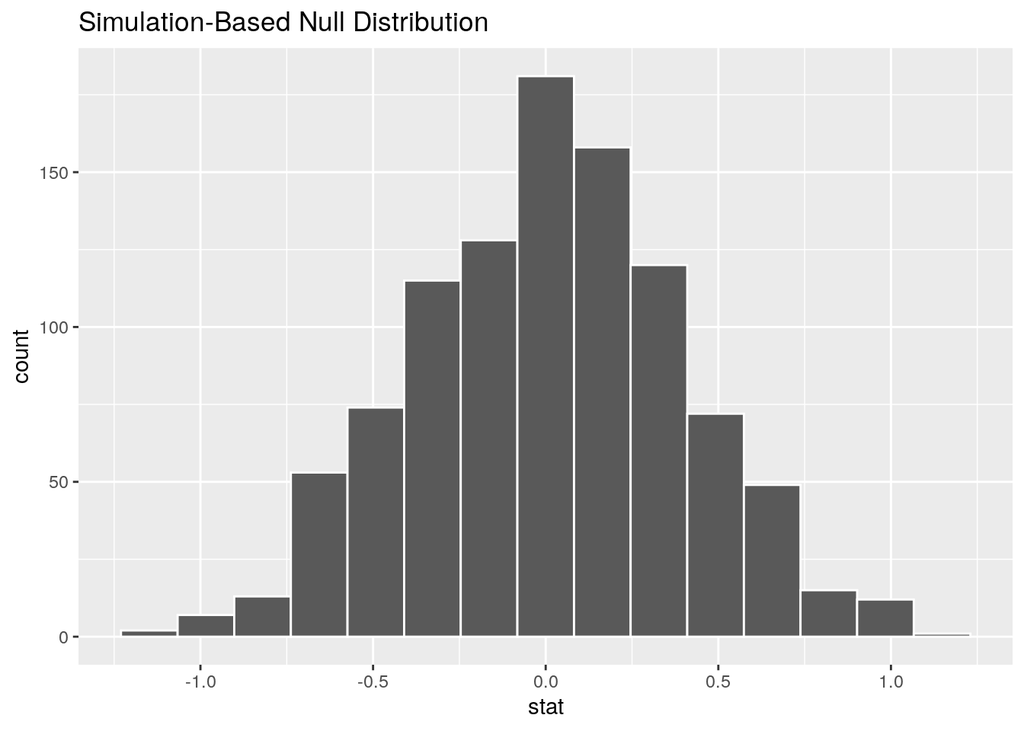

```r
visualize(null_distribution_movies)
```

Now, let's calculate and visualize our p-value. To do this, we need to first calculate: what was the *observed* difference in mean ratings in our dataset? Calculate that here.

```r
# Uncomment this code block and calculate the value of obs_diff_means
obs_diff_means <- movies_sample %>%
  specify(formula = rating ~ genre) %>%
  calculate(stat = "diff in means", order = c("Action", "Romance"))
obs_diff_means
```

```
## # A tibble: 1 × 1
##    stat
##   <dbl>
## 1 -1.05
```

Now check your understanding:

12. What does the shaded area on the graph represent? **The shaded area on the graph represents the p-value associated with the observed difference in means.**

#### Visualize the p-value

Now, let's visualize the p-value on your null distribution. Modify the null distribution histogram you just made to include the p-value and shading (check the textbook examples if you're unsure how).

*Hint: you'll have to specify a `direction` for shading- "both", "right", or "left". Remember that in the gendered resume example, we set this to be "right" because we were testing the hypothesis that male gendered resumes were promoted more often than female gendered resumes. What should you choose here?*

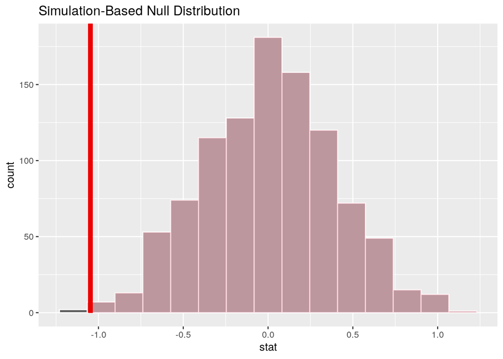

```r
visualize(null_distribution_movies) +
  shade_p_value(obs_stat = obs_diff_means, direction = "right")
```

#### Get the p-value

Finally, let's find the actual number corresponding to the p-value.

```r
p_value <- null_distribution_movies %>%
  get_p_value(obs_stat = obs_diff_means, direction = "right")
p_value
```

```
## # A tibble: 1 × 1
##   p_value
##     <dbl>
## 1   0.998
```

#### What's the result of our hypothesis test?

So- given alpha = 0.05, what should our decision be about our hypotheses?

13. Would you reject the null hypothesis? **Since my p-value is extremely high and defnitely higher thatn 0.05, I would fail to reject the null hypothesis.**
14. Could you explain in plain language what that means? Write as if you were telling a friend who doesn't know about statistics. **The data didn't show a clear enough difference in ratings between action and romance movies. So, we stick with the idea that there's no significant difference (fail to reject the null hypothesis). In simpler terms, we're not convinced action movies definitely get higher ratings than romance movies based on this data.**
15. What would be a pro- and con- of setting alpha higher, at alpha = 0.10? **The pro of setting alpha higher to 0.10 would be *increased sensitivity*, and the con would be *increased Type I error*.**